# Data Analysis Practice

Jiayi Li

2024-09-02

```r
# Load the file
library(readxl)
raw_data <- read_excel("DATA2x02_survey_2024_Responses.xlsx")
```

# 1 Introduction

## 1.1 Is this a random sample of DATA2X02

I think the group of students who enroll in DATA2X02 is not a random sample, here are the reasons:

- **Self-Selection Bias:** Students actively choose to enroll in the course, which might indicate an inherent interest or aptitude for data analysis or related subjects. Those uninterested in data analysis or who feel they lack the necessary skills are unlikely to enroll, meaning the sample may not represent the general student population.
- **Response Bias:** Even if the enrolled students are diverse, the sample of students who respond to the survey might not be random. Those who choose to respond might have stronger opinions, higher engagement with the course, or more time to participate, leading to further bias in the analysis.

## 1.2 What are the potential biases? Which variables are most likely to be subjected to this bias?

- **Non-Response Bias**: Not every students who enrolled in DATA2X02 completed the questionnaire. Some of them may do not have time to complete it, some of them might do not know this things. As for those people who do not know such questionnaire, it might imply that they do not value this unit, which might affect their aiming grade for this unit. It means that the people who completed the questionnaire might have a higher expectation towards the final grade for this unit than the people did not.
- **Selection Bias**: The questionnaire is too long, which means that not every student would have the patience to complete it. Only students who are motivated or interested in data might complete the survey, which may not represent the views of the entire class. Thus, maybe this bias would influence the question “Which unit are you enrolled in?”, because the student who enrolled in DATA2902 might be more interested in this unit.

## 1.3 Which questions needed improvement to generate useful data

- **What is your favourite anime?**: As for this question, the answer we get is too discrete. So I think this question could be changed into “What is your favourite anime’s genres?”. And then the students will be given a list of genres. And it can reduce the scope of answer, and make it easier for people to investigate.
- **What is your favourite social media platform?**: it might lead to inconsistent values, for example the “X”’s previous name is “twitter”, but some student might answer “X”, and some would answer “twitter”, but both of them indicate the same media platform. So I think the improvement for this question is same with above question, which is that the student will be given a list of social media platforms.
- **What is your shoe size?**: it will also lead to inconsistency in data quality, because there are a number of different shoe-size systems used worldwide, thus the same figure might have different meaning at here. So I think the question should add a demand to let people answer in a specific standard (e.g. answer the shoe size in UK system).

## 1.4 Data Cleaning Description

As for Question 1, Question 2 and Question 3, I just omit the missing data directly.

It is worth to mention that: in question 2, I found that there is some outliers (someone say that he spend 1500 hours on studying, but it is apparently impossible). So I set a range to filter the data at here, which is from 0 to 100, so that it can eliminate the influence of outliers.

# 2 Questions

## 2.1 Is there a connection between the students’ daily attitudes and the time they start assignment (Chi-Square test)

The people’s reaction that tend to lean towards saying “yes” or towards saying “no” to things may represent their different attitudes towards the life. And the people prefer to say “yes” may be more optimistic, so that they may be mroe energetic. And it might help them to finish the assignment on time.

## 2.2 Can we say that, as for these students who prefer to say “Yes” in their daily life will spend more time on study? (T-test)

The people who tend to say “yes” may have a stronger desire to learn and explore. So maybe these students will spend more time on study?

## 2.3 Will the people lean to say “No” be easier to feel anxious in their daily life? (Permutation test)

The people who lean to say no might be more cautious, however, “say no” may also help them to avoid many unnecessary trouble caused by other people. Thus, I wonder whether the people who lean to say no will be easier to feel anxious or not.

# 3 Results

## 3.1 Is there a connection between the students’ daily attitudes and the time they start assignment (Chi-Square test)

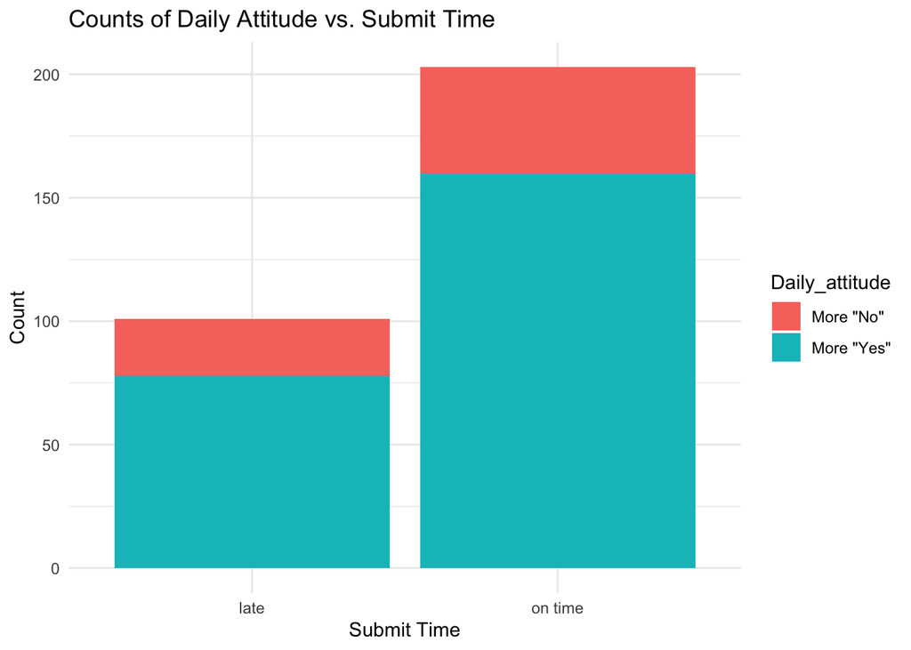

```r
library(dplyr)
library(tidyverse)
library(ggplot2)

# Extract the data
chi_square_data <- select(raw_data, "When it comes to assignments / due tasks do you:", "Do you submit assignments on time?", "Do you tend to lean towards saying \"yes\" or towards saying \"no\" to things throughout life?")

# Rename the columns
chi_square_data <- chi_square_data %>%
  rename(
    daily_attitude = "Do you tend to lean towards saying \"yes\" or towards saying \"no\" to things throughout life?",
    submit_time = "Do you submit assignments on time?"
  )

#remove the rows containing unknown variable
chi_square_data <- na.omit(chi_square_data)

# Form the table
chi_square_data <- chi_square_data %>%
  mutate(submit_time = recode(submit_time,
                         "Always" = "on time",
                         "Usually" = "late",
                         "Sometimes" = "late",
                         "Never" = "late")
         )

chi_square_table <- table(chi_square_data$daily_attitude, chi_square_data$submit_time)

# Do the chi-square test
chi_square_test <- chisq.test(chi_square_table, correct = FALSE)

# Convert the contingency table to a data frame
chi_square_df <- as.data.frame(chi_square_table)
colnames(chi_square_df) <- c("daily_attitude", "submit_time", "Count")
ggplot(chi_square_df, aes(x = submit_time, y = Count, fill = daily_attitude)) +
  geom_col() +  # Use "dodge" for side-by-side bars
  labs(title = "Counts of Daily Attitude vs. Submit Time",
       x = "Submit Time",
       y = "Count",
       fill = "Daily_attitude") +
  theme_minimal()
```

### Hypotheses test(Larsen 2012a)

- H: Hypotheses
  - $H_0$: The students’ attitudes is independent of whether they can submit their assignments on time.
  - $H_1$: The students’ attitudes is not independent of whether they can submit their assignments on time.
- A: Assumptions
  - Each students complete their questionnaires independently.
- T: Test statistic
  - Test statistic: T = 0.1003161, under t ~ $X^2_1$
- P: P-value
  - P-value: P-value = 0.7514507
- C: Conclusion
  - The students’ daily attitude would not affect the time they submit their assignments

### Check Assumptions

- **Independence**: Each student complete this questionnaire independently, so we can regard the every entry we got is independent.
- **Categorical Data**: In this test, both variables are categorical.
- **Sample Size**: As we can see in the bar plot, the sample size are big enough no matter for which category.

### Limitations

In this Chi-square test, we classify the “Usually”, “Sometimes” and “Never” to the late group. At here, I think different people would have different view towards usually, so I just classify the “Usually” into the late group directly (which means that they cannot submit assignments on time every time). And it might group some students into this “late” group by mistake, and it might lead to an inaccurate result.

## 3.2 Can we say that, as for these students who prefer to say “Yes” in their daily life will spend more time on study? (T-test)

### Hypotheses test

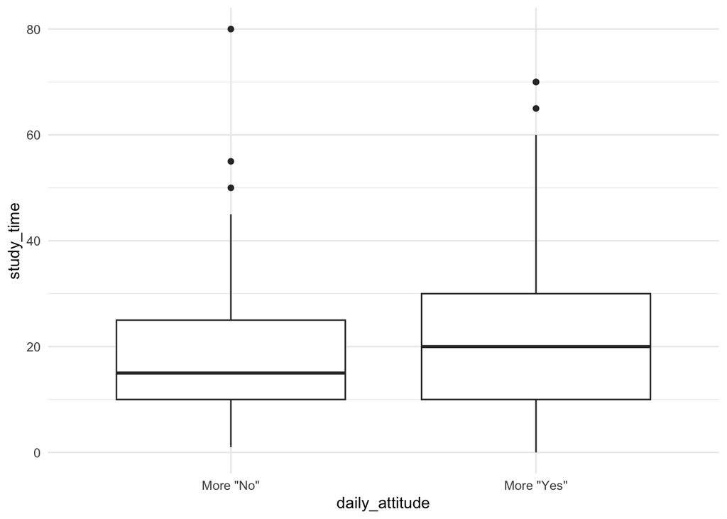

```r
library(dplyr)
library(tidyverse)
library(ggplot2)

# Extract the data
t_test_data <- select(raw_data, "Do you tend to lean towards saying \"yes\" or towards saying \"no\" to things throughout life?", "How many hours a week do you spend studying?")

# Rename the columns
t_test_data <- t_test_data |>
  rename(
    daily_attitude = "Do you tend to lean towards saying \"yes\" or towards saying \"no\" to things throughout life?",
    study_time = "How many hours a week do you spend studying?"
  )

# Remove the rows containing unknown variable
t_test_data <- na.omit(t_test_data)

# Draw the box plot
filtered_data <- subset(t_test_data, study_time>=0 & study_time<100)
filtered_data |>
  ggplot() +
  aes(x = daily_attitude, y = study_time) +
  geom_boxplot() +
  theme_minimal()
```

```r
# Extract the study time according to their attitude
accept <- filtered_data %>%
  filter(daily_attitude == "More \"Yes\"")
refuse <- filtered_data %>%
  filter(daily_attitude == "More \"No\"")

t_test_result <- t.test(accept$study_time, refuse$study_time,
       alternative = "two.sided",
       var.equal = FALSE)
```

- H: Hypotheses
  - $H_0$: The students who prefer to say yes spend the same time on studying as the students who prefer to say no.
  - $H_1$: The students who prefer to say yes spend the different time on studying as the students who prefer to say no.
- A: Assumptions
  - Both groups of students are identical and independent distributed random variables
  - And the two students’ group are independent to each other.
- T: Test statistic
  - Test statistic: T = 1.4063278
- P: P-value
  - P-value: P-value = 0.1626181
- C: Conclusion
  - The students who prefer to say yes spend the same time on studying as the students who prefer to say no.

### Check Assumptions

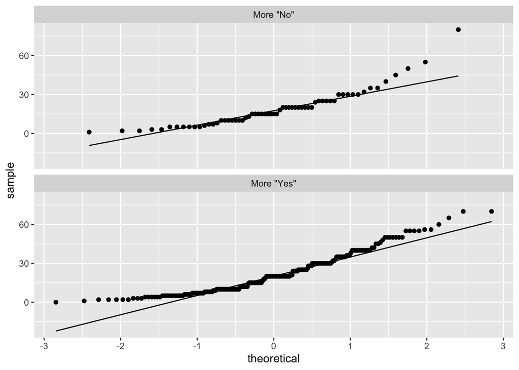

```r
library(dplyr)
library(ggplot2)

filtered_data |>
  ggplot() +
  aes(sample = study_time, group = daily_attitude) +
  geom_qq_line() + geom_qq() +
  facet_wrap(~daily_attitude, nrow = 2)
```

This suggests that the data for “More No” may not follow a normal distribution, while the data for “More Yes” might be closer to normal, but still with some deviations.

### Limitation of tests

Dut to the data appears not to be normally distributed, applying a parametric test like the T-test could lead to unreliable results. (Larsen 2012b)

## 3.3 Will the people lean to say “No” be easier to feel anxious in their daily life? (Permutation test)

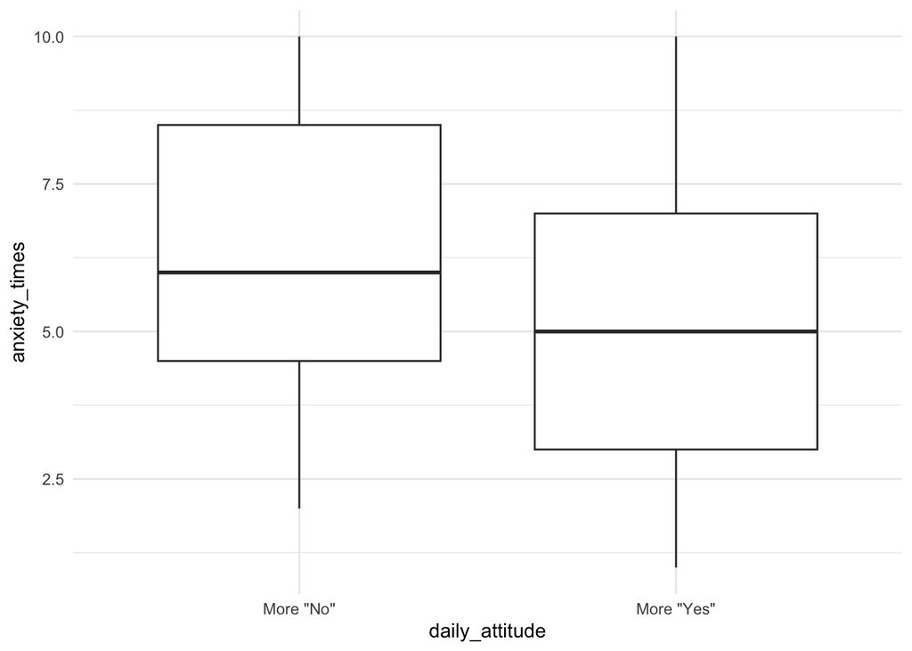

```r
library(tidyverse)
library(ggplot2)
library(dplyr)

# Extract data
permutation_test_data <- select(raw_data, "How often would you say you feel anxious on a daily basis?", "Do you tend to lean towards saying \"yes\" or towards saying \"no\" to things throughout life?")

# Rename the columns
permutation_test_data <- permutation_test_data |>
  rename(
    daily_attitude = "Do you tend to lean towards saying \"yes\" or towards saying \"no\" to things throughout life?",
    anxiety_times = "How often would you say you feel anxious on a daily basis?"
  )

# Remove the rows containing unknown variable
permutation_test_data <- na.omit(permutation_test_data)

permutation_test_data |> ggplot() +
  aes(x = daily_attitude, y = anxiety_times) +
  geom_boxplot(coef = 10) +
  theme_minimal()
```

```r
# Do the permutation test
t0_original <- wilcox.test(anxiety_times ~ daily_attitude, data = permutation_test_data)$statistic
set.seed(1)
B = 10000 # number of permuted samples we will consider
permuted_data <- permutation_test_data # make a copy of the data
t_null = vector("numeric", B) # initialise outside loop
for (i in 1:B) {
  permuted_data$daily_attitude = sample(permutation_test_data$daily_attitude) # this does the permutation
  t_null[i] = wilcox.test(anxiety_times ~ daily_attitude, data = permuted_data)$statistic
}
p_value <- mean(t_null >= t0_original)*2
```

### Hypotheses test(Wilber 2019)

- H: Hypotheses
  - $H_0$: The two groups of students have the same frequencies to feel anxioust in their daily life.
  - $H_1$: The two groups of students have the different frequencies to feel anxioust in their daily life.
- A: Assumptions
  - The two students’ group are independent to each other.
- T: Test statistic
  - Test statistic: T = 9925
- P: P-value
  - P-value: P-value = 0.0032

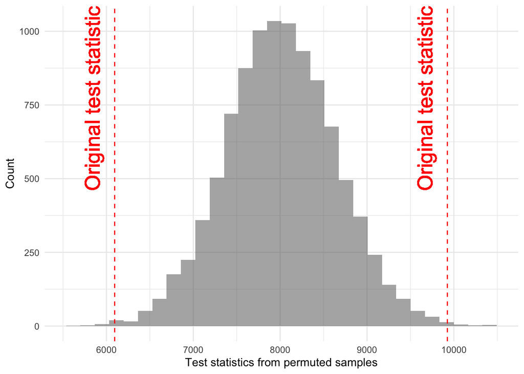

```r
library(ggplot2)
t_null |> data.frame() |> ggplot() + aes(x = t_null) +
  geom_histogram(alpha=0.5) +
  geom_vline(xintercept = 2*mean(t_null) - t0_original, colour = "red", linetype = "dashed") +
  geom_text(aes(x = 2*mean(t_null) - t0_original, label = "Original test statistic", y = Inf),
            colour = "red", angle = 90, hjust = 1, vjust = -1, size = 7) +
  geom_vline(xintercept = t0_original, colour = "red", linetype = "dashed") +
  geom_text(aes(x = t0_original, label = "Original test statistic", y = Inf),
            colour = "red", angle = 90, hjust = 1, vjust = -1, size = 7) +
  labs(x = "Test statistics from permuted samples", y = "Count") +
  theme_minimal()
```

- C: Conclusion
  - The two groups of students have the different frequencies to feel anxioust in their daily life.

### Check Assumptions

As we state in the Chi-Square test, each student complete this questionnaire independently, so we can regard the every entry we got is independent.

# 4 Conclusion

From the question 1, we know that there is no obvious connection between the students’ daily attitudes and if they can submit assignments on time.

And from question 2, we can get the conclusion that their daily attitudes would not affect the time they spend on studying.

However, we can see that the people who tend to lean towards saying “no” to things will have a higher frequencies to feel anxious in their daily life compared to the people who tend to lean towards saying “yes”.

And it might because the people who prefer lean saying “yes” would be more optimistic in their daily life, so that it can help them to deal with their daily challenges, and then it might help them to relieve their anxiety.(Gressel 2018)

# References

Gressel, Josh. 2018. “Are You Saying Yes to Life?” https://www.psychologytoday.com/us/blog/putting-psyche-back-psychotherapy/201810/are-you-saying-yes-life.

Larsen, & Marx, R. J. 2012b. “An Introduction to Mathematical Statistics and Its Applications (5th Ed.).” In, 350–418. Pearson Education, Inc.

———. 2012a. “An Introduction to Mathematical Statistics and Its Applications (5th Ed.).” In, 499–518. Pearson Education, Inc.

Wilber, Jared. 2019. “The Permutation Test.” https://www.jwilber.me/permutationtest/.